# LandR *Biomass_core* Manual

Last updated: 2026-10-30

#### Authors:

Yong Luo yluo1@lakeheadu.ca [aut], Eliot J B McIntire eliot.mcintire@nrcan-rncan.gc.ca [aut, cre], Ceres Barros ceres.barros@ubc.ca [aut], Alex M. Chubaty achubaty@for-cast.ca [aut], Ian Eddy ian.eddy@nrcan-rncan.gc.ca [ctb], Jean Marchal jean.d.marchal@gmail.com [ctb]

**This documentation is work in progress. Potential discrepancies and omissions may exist for the time being. If you find any, contact us using the “Get help” link above.**

## Module Overview

### Quick links

- General functioning
- List of input objects
- List of parameters
- List of outputs
- Simulation flow and module events

### Summary

LandR *Biomass_core* (hereafter *Biomass_core*) is the core forest succession simulation module of the LandR ecosystem of `SpaDES` modules (see Chubaty & McIntire 2019). It simulates tree cohort ageing, growth, mortality and competition for light resources, as well as seed dispersal (Fig. 1), in a spatially explicit manner and using a yearly time step. The model is based on the LANDIS-II Biomass Succession Extension v.3.2.1 (LBSE, Scheller & Miranda 2015), with a few changes (see Differences between *Biomass_core* and LBSE). Nonetheless, the essential functioning of the succession model still largely follows its LANDIS-II counterpart, and we refer the reader to the corresponding LBSE manual (Scheller & Miranda 2015) for a detailed reading of the mechanisms implemented in the model.

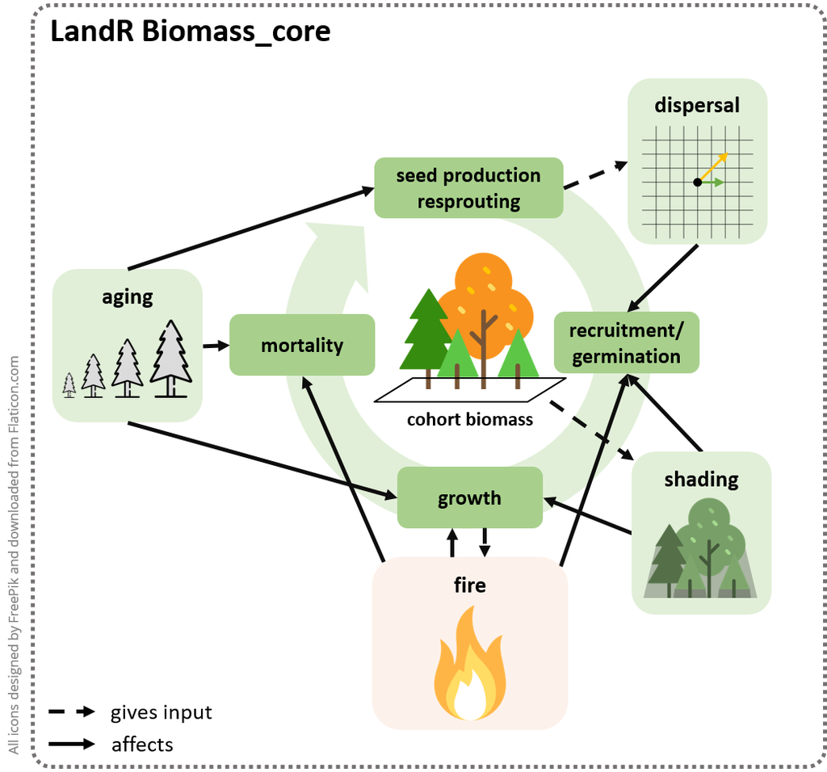

Figure 1: *Biomass_core* simulates tree cohort growth, mortality, recruitment and dispersal dynamics, as a function of cohort ageing and competition for light (shading) and space, as well as disturbances like fire (simulated using other modules).

### Links to other modules

*Biomass_core* is intended to be used with data/calibration modules, disturbance modules and validation modules, amongst others. The following is a list of the modules most commonly used with *Biomass_core*. For those not yet in the [LandR Manual](https://landr-manual.predictiveecology.org/) see the individual module’s documentation (`.Rmd` file) available in its repository.

See [here](https://rpubs.com/PredictiveEcology/LandR_Module_Ecosystem) for all available modules and select *Biomass_core* from the drop-down menu to see linkages.

**Data and calibration modules:**

- [*Biomass_speciesData*](https://github.com/PredictiveEcology/Biomass_speciesData): grabs and merges several sources of species cover data, making species percent cover (% cover) layers used by other LandR Biomass modules. Default source data spans the entire Canadian territory;
- [*Biomass_borealDataPrep*](https://github.com/PredictiveEcology/Biomass_borealDataPrep): prepares all parameters and inputs (including initial landscape conditions) that *Biomass_core* needs to run a realistic simulation. Default values/inputs produced are relevant for boreal forests of Western Canada;
- [*Biomass_speciesParameters*](https://github.com/PredictiveEcology/Biomass_speciesParameters): calibrates four-species level traits using permanent sample plot data (i.e., repeated tree biomass measurements) across Western Canada.

**Disturbance-related modules:**

- [*Biomass_regeneration*](https://github.com/PredictiveEcology/Biomass_regeneration): simulates cohort biomass responses to stand-replacing fires (as in LBSE), including cohort mortality and regeneration through resprouting and/or serotiny;
- [*Biomass_regenerationPM*](https://github.com/PredictiveEcology/Biomass_regenerationPM): like *Biomass_regeneration*, but allowing partial mortality. Based on the LANDIS-II Dynamic Fuels & Fire System extension (Sturtevant *et al.* 2018);
- *fireSense*: climate- and land-cover-sensitive fire model simulating fire ignition, escape and spread processes as a function of climate and land-cover. Includes built-in parameterisation of these processes using climate, land-cover, fire occurrence and fire perimeter data. Requires using *Biomass_regeneration* or *Biomass_regenerationPM*. See modules prefixed “*fireSense_*” at https://github.com/PredictiveEcology/;
- [*LandMine*](https://github.com/PredictiveEcology/LandMine): wildfire ignition and cover-sensitive wildfire spread model based on a fire return interval input. Requires using *Biomass_regeneration* or *Biomass_regenerationPM*;
- [*scfm*](https://github.com/PredictiveEcology/scfm): spatially explicit fire spread module parameterised and modelled as a stochastic three-part process of ignition, escape, and spread. Requires using *Biomass_regeneration* or *Biomass_regenerationPM*.

**Validation modules:**

- [*Biomass_validationKNN*](https://github.com/PredictiveEcology/Biomass_validationKNN): calculates two validation metrics (mean absolute deviation and sum of negative log-likelihoods) on species presences/absences and biomass-related properties across the simulated landscape. By default, it uses an independent dataset of species % cover and stand biomass for 2011, assuming that this is a second snapshot of the landscape.

## Module manual

### General functioning

*Biomass_core* is a forest landscape model based on the LANDIS-II Biomass Succession Extension v.3.2.1 model (LBSE, Scheller & Miranda 2015). It is the core forest succession model of the LandR ecosystem of `SpaDES` modules. Similarly to LBSE, *Biomass_core* simulates changes in tree cohort aboveground biomass ($g/m^2$) by calculating growth, mortality and recruitment as functions of pixel and species characteristics, competition and disturbances (Fig. 1). Note that, by default, cohorts are unique combinations of species and age, but this can be changed via the `cohortDefinitionCols` parameter (see List of parameters).

Specifically, cohort growth is driven by both invariant (growth shape parameter, `growthcurve`) and spatio-temporally varying species traits (maximum biomass, `maxB`, and maximum annual net primary productivity, `maxANPP`), while background mortality (i.e., not caused by disturbances) depends only on invariant species traits (`longevity` and mortality shape parameter, `mortalityshape`). All these five traits directly influence the realised shape of species growth curves, by determining how fast they grow (`growthcurve` and `maxANPP`), how soon age mortality starts with respect to longevity (`mortalityshape`) and the biomass a cohort can potentially achieve (`maxB`).

Cohort recruitment is determined by available “space” (i.e., pixel shade), invariant species traits (regeneration mode, `postfireregen`, age at maturity, `sexualmature`, shade tolerance, `shadetolerance`) and a third spatio-temporally varying trait (species establishment probability, `establishprob`, called SEP hereafter). The available “growing space” is calculated as the species’ `maxB` minus the occupied biomass (summed across other cohorts in the pixel). If there is “space”, a cohort can establish from one of three recruitment modes: serotiny, resprouting and germination.

Disturbances (e.g., fire) can cause cohort mortality and trigger post-disturbance regeneration. Two post-disturbance regeneration mechanisms have been implemented, following LBSE: serotiny and resprouting (Scheller & Miranda 2015). Post-disturbance mortality and regeneration only occur in response to fire and are simulated in two separate, but interchangeable modules, *Biomass_regeneration* and *Biomass_regenerationPM* that differ with respect to the level of post-fire mortality they simulate (complete or partial mortality, respectively).

Cohort germination (also called cohort establishment) occurs if seeds are available from local sources (the pixel), or via seed dispersal. Seed dispersal can be of three modes: ‘no dispersal’, ‘universal dispersal’ (arguably, only interesting for dummy case studies) or ‘ward dispersal’ (Scheller & Miranda 2015). Briefly, the ‘ward dispersal’ algorithm describes a flexible kernel that calculates the probability of a species colonising a neighbour pixel as a function of distance from the source and dispersal-related (and invariant) species traits, and is used by default.

Finally, both germination and regeneration success depend on the species’ probability of germination in a given pixel (probabilities of germination).

We refer the reader to Scheller & Miranda (2015), Scheller & Domingo (2011) and Scheller & Domingo (2012) for further details with respect to the above mentioned mechanisms implemented in *Biomass_core*. In a later section of this manual, we highlight existing differences between *Biomass_core* and LBSE, together with comparisons between the two modules.

### Initialisation, inputs and parameters

To initialise and simulate forest dynamics in any given landscape, *Biomass_core* requires a number of inputs and parameters namely:

- initial cohort biomass and age values across the landscape;
- invariant species traits values;
- spatio-temporally varying species traits values (or just spatially-varying);
- location- (ecolocation-) specific parameters;
- and the probabilities of germination given a species’ shade tolerance and site shade.

These are detailed below and in the full list of input objects. The *Biomass_borealDataPrep* module manual also provides information about the estimation of many of these traits/inputs from available data, or their adjustment using published values or our best knowledge of boreal forest dynamics in Western Canada.

Unlike the initialisation in LBSE[^1], *Biomass_core* initialises the simulation using data-derived initial cohort biomass and age. This information is ideally supplied by data and calibration modules like *Biomass_borealDataPrep* (Links to other modules), but *Biomass_core* can also initialise itself using theoretical data.

Similarly, although *Biomass_core* can create all necessary traits and parameters using theoretical values, for realistic simulations these should be provided by data and calibration modules, like *Biomass_borealDataPrep* and *Biomass_speciesParameters*. We advise future users and developers to become familiar with these data modules and then try to create their own modules (or modify existing ones) for their purpose.

#### Initial cohort biomass and age

Initial cohort biomass and age are derived from stand biomass (`biomassMap` raster layer), stand age (`standAgeMap` raster layer) and species % cover (`speciesLayers` raster layers) data (see Table 5) and formatted into the `cohortData` object. The `cohortData` table is a central simulation object that tracks the current year’s cohort biomass, age, mortality (lost biomass) and aboveground net primary productivity (ANPP) per species and pixel group (`pixelGroup`). At the start of the simulation, `cohortData` will not have any values of cohort mortality or ANPP.

Each `pixelGroup` is a collection of pixels that share the same ecolocation (coded in the `ecoregionMap` raster layer) and the same cohort composition. By default, an ecolocation is a combination of land-cover and ecological zonation (see `ecoregionMap` in the full list of inputs) and unique cohort compositions are defined as unique combinations of species, age and biomass. The `cohortData` table is therefore always associated with the current year’s `pixelGroupMap` raster layer, which provides the spatial location of all `pixelGroups`, allowing to “spatialise” cohort information and dynamics (e.g., dispersal) on a pixel by pixel basis (see also Hashing).

The user, or another module, may provide initial `cohortData` and `pixelGroupMap` objects to start the simulation, or the input objects necessary to produce them: a study area polygon (`studyArea`), the `biomassMap`, `standAgeMap`, `speciesLayers` and `ecoregionMap` raster layers (see the list of input objects for more detail).

#### Invariant species traits

These are spatio-temporally constant traits that mostly influence population dynamics (e.g., growth, mortality, dispersal) and responses to fire (fire tolerance and regeneration).

By default, *Biomass_core* obtains trait values from available LANDIS-II tables (see Table 5), but traits can be adjusted/supplied by the user or by other modules. For instance, using *Biomass_borealDataPrep* will adjust some trait values for Western Canadian boreal forests (e.g., longevity values are adjusted following Burton & Cumming 1995), while using *Biomass_speciesParameters* calibrates the `growthcurve` and `mortalityshape` parameters and estimates two additional species traits (`inflationFactor` and `mANPPproportion`) to calibrate `maxB` and `maxANPP` (respectively).

Table 1 shows an example of a table of invariant species traits. Note that *Biomass_core* (alone) requires all the columns Table 1 in to be present, with the exception of `firetolerance`, `postfireregen`, `resproutprob`, `resproutage_min` and `resproutage_max`, which are used by the post-fire regeneration modules (*Biomass_regeneration* and *Biomass_regenerationPM*).

Please see Scheller & Domingo (2011) and Scheller & Miranda (2015) for further detail.

Table 1: Example of an invariant species traits table (the `species` table object in the module), with species *Abies sp.* (Abie_sp), *Picea engelmannii* (Pice_eng), *Picea glauca* (Pice_gla), *Pinus sp.* (Pinu_sp), *Populus sp.* (Popu_sp) and *Pseudotsuga menziesii* (Pseu_men). Note that these are theoretical values.

| speciesCode | longevity | sexualmature | shadetolerance | firetolerance | postfireregen | resproutprob | resproutage_min | resproutage_max | seeddistance_eff | seeddistance_max | mortalityshape | growthcurve |
| --- | --- | --- | --- | --- | --- | --- | --- | --- | --- | --- | --- | --- |
| Abie_sp | 200 | 20 | 2.3 | 1 | none | 0.0 | 0 | 0 | 25 | 100 | 15 | 0 |
| Pice_eng | 460 | 30 | 2.1 | 2 | none | 0.0 | 0 | 0 | 30 | 250 | 15 | 1 |
| Pice_gla | 400 | 30 | 1.6 | 2 | none | 0.0 | 0 | 0 | 100 | 303 | 15 | 1 |
| Pinu_sp | 150 | 15 | 1.0 | 2 | serotiny | 0.0 | 0 | 0 | 30 | 100 | 15 | 0 |
| Popu_sp | 140 | 20 | 1.0 | 1 | resprout | 0.5 | 10 | 70 | 200 | 5000 | 25 | 0 |
| Pseu_men | 525 | 25 | 2.0 | 3 | none | 0.0 | 0 | 0 | 100 | 500 | 15 | 1 |

#### Spatio-temporally varying species traits

These traits vary between species, by ecolocation and, potentially, by year if the `year` column is not omitted and several years exist (in which case last year’s values up to the current simulation year are always used). They are maximum biomass, `maxB`, maximum above-ground net primary productivity, `maxANPP`, and species establishment probability, SEP (called `establishprob` in the module). By default, *Biomass_core* assigns theoretical values to these traits, and thus we recommend using *Biomass_borealDataPrep* to obtain realistic trait values derived from data (by default, pertinent for Canadian boreal forest applications), or passing a custom table directly. *Biomass_speciesParameters* further calibrates `maxB` and `maxANPP` by estimating two additional invariant species traits (`inflationFactor` and `mANPPproportion`; also for Western Canadian forests). See Table 2 for an example.

Table 2: Example of a spatio-temporally varying species traits table (the `speciesEcoregion` table object in the module), with two ecolocations (called `ecoregionGroups`) and species *Abies sp.* (Abie_sp), *Picea engelmannii* (Pice_eng), *Picea glauca* (Pice_gla), *Pinus sp.* (Pinu_sp), *Populus sp.* (Popu_sp) and *Pseudotsuga menziesii* (Pseu_men). If a simulation runs for 10 year using this table, trait values from year 2 would be used during simulation years 2-10.

| ecoregionGroup | speciesCode | establishprob | maxB | maxANPP | year |
| --- | --- | --- | --- | --- | --- |
| 1_03 | Abie_sp | 1.000 | 8567 | 285 | 1 |
| 1_03 | Pice_eng | 0.983 | 10156 | 305 | 1 |
| 1_03 | Popu_sp | 0.737 | 8794 | 293 | 1 |
| 1_03 | Pseu_men | 1.000 | 17534 | 132 | 1 |
| 1_09 | Abie_sp | 0.112 | 1499 | 50 | 1 |
| 1_09 | Pice_gla | 0.302 | 3143 | 102 | 1 |
| 1_09 | Pinu_sp | 0.714 | 2569 | 86 | 1 |
| 1_09 | Popu_sp | 0.607 | 3292 | 110 | 1 |
| 1_09 | Pseu_men | 0.997 | 6020 | 45 | 1 |
| 1_03 | Abie_sp | 0.989 | 8943 | 225 | 2 |
| 1_03 | Pice_eng | 0.985 | 9000 | 315 | 2 |
| 1_03 | Popu_sp | 0.600 | 8600 | 273 | 2 |
| 1_03 | Pseu_men | 1.000 | 13534 | 142 | 2 |
| 1_09 | Abie_sp | 0.293 | 2099 | 45 | 2 |
| 1_09 | Pice_gla | 0.745 | 3643 | 90 | 2 |
| 1_09 | Pinu_sp | 0.500 | 2569 | 80 | 2 |
| 1_09 | Popu_sp | 0.670 | 3262 | 111 | 2 |
| 1_09 | Pseu_men | 1.000 | 6300 | 43 | 2 |

#### Ecolocation-specific parameters – minimum relative biomass

Minimum relative biomass (`minRelativeB`) is the only ecolocation-specific parameter used in *Biomass_core*. It is used to determine the shade level in each pixel (i.e., site shade) with respect to the total potential maximum biomass for that pixel (i.e., the sum of all `maxB` values in the pixel’s ecolocation). If relative biomass in the stand (with regards to the total potential maximum biomass) is above the minimum relative biomass thresholds, the pixel is assigned that threshold’s site shade value (Scheller & Miranda 2015).

The shade level then influences the germination and regeneration of new cohorts, depending on their shade tolerance (see Probabilities of germination).

Site shade varies from X0 (no shade) to X5 (maximum shade). By default, *Biomass_core* uses the same minimum realtive biomass threshold values across all ecolocations, adjusted from a [publicly available LANDIS-II table](https://github.com/dcyr/LANDIS-II_IA_generalUseFiles) to better reflect Western Canada boreal forest dynamics (see Table 3). *Biomass_borealDataPrep* does the same adjustment by default. As with other inputs, these values can be adjusted by using other modules or by passing user-defined tables.

Table 3: Example of a minimum relative biomass table (the `minRelativeB` table object in the module), with two ecolocations (`ecoregionGroups`) sharing the same values

| ecoregionGroup |  |  |  |  |  |
| --- | --- | --- | --- | --- | --- |
| 1_03 | 0.15 | 0.25 | 0.5 | 0.75 | 0.85 |
| 1_09 | 0.15 | 0.25 | 0.5 | 0.75 | 0.85 |

#### Probabilities of germination

A species’ probability of germination results from the combination of its shade tolerance level (an invariant species trait in the `species` table; Table 1) and the site shade – defined by the amount of biomass in the pixel, see minimum relative biomass parameter – (Scheller & Miranda 2015). By default, both *Biomass_core* and *Biomass_borealDataPrep* use a publicly available LANDIS-II table (called `sufficientLight` in the module; Table 4).

Table 4: Default species probability of germination values used by *Biomass_core* and *Biomass_borealDataPrep*. Columns X0-X5 are different site shade levels and each line has the probability of germination for each site shade and species shade tolerance combination.

| species shade tolerance | X0 | X1 | X2 | X3 | X4 | X5 |
| --- | --- | --- | --- | --- | --- | --- |
| 1 | 1 | 0 | 0 | 0 | 0 | 0 |
| 2 | 1 | 1 | 0 | 0 | 0 | 0 |
| 3 | 1 | 1 | 1 | 0 | 0 | 0 |
| 4 | 1 | 1 | 1 | 1 | 0 | 0 |
| 5 | 0 | 0 | 1 | 1 | 1 | 1 |

#### Other module inputs

The remaining module input objects either do not directly influence the basic mechanisms implemented in *Biomass_core* (e.g., `sppColorVect` and `studyAreaReporting` are only used for plotting purposes), are objects that keep track of a property/process in the module (e.g., `lastReg` is a counter of the last year when regeneration occurred), or define the study area for the simulation (e.g., `studyArea` and `rasterToMatch`).

The next section provides a complete list of all input objects, including those already mentioned above.

### List of input objects

All of *Biomass_core*’s input objects have (theoretical) defaults that are produced automatically by the module[^2]. We suggest that new users run *Biomass_core* by itself supplying only a `studyArea` polygon, before attempting to supply their own or combining *Biomass_core* with other modules. This will enable them to become familiar with all the input objects in a theoretical setting.

Of the inputs listed in Table 5, the following are particularly important and deserve special attention:

**Spatial layers**

- `ecoregionMap` – a raster layer with ecolocation IDs. Note that the term “ecoregion” was inherited from LBSE and kept for consistency with original LBSE code, but we prefer to call them ecolocations to avoid confusion with the ecoregion-level classification of the [National Ecological Classification of Canada (NECC)](https://open.canada.ca/data/en/dataset/3ef8e8a9-8d05-4fea-a8bf-7f5023d2b6e1). Ecolocations group pixels with similar biophysical conditions. By default, we use two levels of grouping in our applications: the first level being an ecological classification such as ecodistricts from the NECC, and the second level is a land-cover classification. Hence, these ecolocations contain relatively coarse scale regional information plus finer scale land cover information. The `ecoregionMap` layer must be defined as a categorical raster, with an associated Raster Attribute Table (RAT; see, e.g., `raster::ratify`). The RAT must contain the columns: `ID` (the value in the raster layer), `ecoregion` (the first level of grouping) and `ecoregionGroup` (the full ecolocation “name” written as <firstlevel_secondlevel>). Note that if creating `ecoregionGroup`’s by combining two raster layers whose values are numeric (as in *Biomass_borealDataPrep*), the group label is a character combination of two numeric grouping levels. For instance, if Natural Ecoregion `2` has land-cover types `1`, `2` and `3`, the RAT will contain `ID = {1,2,3}`, `ecoregion = {2}` and `ecoregionGroup = {2_1, 2_2, 2_3}`. However, the user is free to use any groupings they wish. Finally, note that all ecolocations (`ecoregionGroup`’s) are should be listed in the `ecoregion` table.
- `rasterToMatch` – a RasterLayer, with a given resolution and projection determining the pixels (i.e., non-NA values) where forest dynamics will be simulated. Needs to match `studyArea`. If not supplied, *Biomass_core* attempts to produce it from `studyArea`, using `biomassMap` as the template for spatial resolution and projection.
- `studyArea` – a `SpatialPolygonsDataFrame` with a single polygon determining the where the simulation will take place. This is the only input object that **must be supplied by the user or another module**.
- `speciesLayers` – layers of species % cover data. Default data currently comes from the Spatialized Canadian National Forest Inventory [`SCANFI`; Guindon *et al.* (2023), Guindon *et al.* (2024)], a raster-based database of forest characteristics including species covers. The species must match those available in default (or provided) species traits tables (the `species` and `speciesEcoregion` tables).

**Species traits and other parameter tables**

- `ecoregion` – a `data.table` listing all ecolocation “names” (*ecoregionGroup* column; see `ecoregionMap` above for details) and their state (active – `yes` – or inactive – `no`)
- `minRelativeB` – a `data.table` of minimum relative biomass values. See Ecolocation-specific parameters – minimum relative biomass.
- `species` – a `data.table` of invariant species traits.
- `speciesEcoregion` – a `data.table` of spatio-temporally varying species traits.
- `sufficientLight` – a `data.table` defining the probability of germination for a species, given its `shadetolerance` level (see `species` above) and the shade level in the pixel (see `minRelativeB` above). See Probabilities of germination.
- `sppEquiv` – a `data.table` of species name equivalences between various conventions. It must contain the columns *LandR* (species IDs in the LandR format), *EN_generic_short* (short generic species names in English – or any other language – used for plotting), *Type* (type of species, *Conifer* or *Deciduous*, as in “broadleaf”) and *Leading* (same as *EN_generic_short* but with “leading” appended – e.g., “Poplar leading”). See `?LandR::sppEquivalencies_CA` for more information.
- `sppColorVect` – character. A named vector of colours used to plot species dynamics. Should contain one colour per species in the `species` table and, potentially a colour for species mixtures (named “Mixed”). Vector names must follow `species$speciesCode`.
- `sppNameVector` – (OPTIONAL) a character vector of species to be simulated. If provided, *Biomass_core* uses this vector to (attempt to) obtain `speciesLayers` for the listed species. If not provided, the user (or another module) can pass a filtered `sppEquiv` table (i.e., containing only the species that are to be simulated). If neither is provided, then *Biomass_core* attempts to use any species for which if finds available species % cover data in the study area.

**Cohort-simulation-related objects**

- `cohortData` – a `data.table` containing initial cohort information per `pixelGroup` (see `pixelGroupMap` below). This table is updated during the simulation as cohort dynamics are simulated. It must contain the following columns:
  - *pixelGroup* – integer. *pixelGroup* ID. See Hashing.
  - *ecoregionGroup* – character. Ecolocation names. See `ecoregionMap` and `ecoregion` objects above.
  - *speciesCode* – character. Species ID.
  - *age* – integer. Cohort age.
  - *B* – integer. Cohort biomass of the current year in $g/m^2$.
  - *mortality* – integer. Cohort dead biomass of the current year in $g/m^2$. Usually filled with 0s in initial conditions.
  - *aNPPAct* – integer. Actual aboveground net primary productivity of the current year in $g/m^2$. `B` is the result of the previous year’s `B` minus the current year’s `mortality` plus `aNPPAct`. Usually filled with 0s in initial conditions. See “*1.1.3 Cohort growth and ageing*” section of Scheller & Miranda (2015).
- `pixelGroupMap` – a raster layer with `pixelGroup` IDs per pixel. Pixels are always grouped based on identical `ecoregionGroup`, `speciesCode`, `age` and `B` composition, even if the user supplies other initial groupings (e.g., this is possible in the *Biomass_borealDataPrep* data module).

Table 5: List of *Biomass_core* input objects and their description.

| objectName | objectClass | desc | sourceURL |
| --- | --- | --- | --- |
| biomassMap | SpatRaster | Total biomass raster layer in study area (in $g/m^2$), filtered for pixels covered by `cohortData.` Only used if `P(sim)$initialBiomassSource == 'biomassMap'`, which is currently deactivated. |  |
| cceArgs | list | A list of quoted objects used by the `growthAndMortalityDriver` `calculateClimateEffect` function | NA |
| cohortData | data.table | `data.table` with cohort-level information on age and biomass, by `pixelGroup` and ecolocation (i.e., `ecoregionGroup`). If supplied, it must have the following columns: `pixelGroup` (integer), `ecore… | NA |
| columnsForPixelGroups | character | Optional. If not supplied, will use LandR::columnsForPixelGroups(); see ?LandR::columnsForPixelGroups() | NA |
| ecoregion | data.table | Ecoregion look up table | https://raw.githubusercontent.com/LANDIS-II-Foundation/Extensions-Succession/master/biomass-succession-archive/trunk/tests/v6.0-2.0/ecoregions.txt |
| ecoregionMap | SpatRaster | Ecoregion map that has mapcodes matching the `ecoregion` and `speciesEcoregion` tables. Defaults to a dummy map matching `rasterToMatch` with two regions | NA |
| lastReg | numeric | An internal counter keeping track of when the last regeneration event occurred | NA |
| minRelativeB | data.frame | table defining the relative biomass cut points to classify stand shadeness. Needed when `cohortData` and `pixelGroupMap` are supplied; otherwise it is made together with them (dummy version) | NA |
| pixelGroupMap | SpatRaster | A raster layer with `pixelGroup` IDs per pixel. Pixels are grouped based on identical `ecoregionGroup`, `speciesCode`, `age` and `B` composition, even if the user supplies other initial groupings (e.g… | NA |
| rasterToMatch | SpatRaster | A raster of the `studyArea` in the same resolution and projection as `biomassMap` | NA |
| species | data.table | A table of invariant species traits with the following trait colums: ‘species’, ‘Area’, ‘longevity’, ‘sexualmature’, ‘shadetolerance’, ‘firetolerance’, ‘seeddistance_eff’, ‘seeddistance_max’, ‘resprou… | https://raw.githubusercontent.com/dcyr/LANDIS-II_IA_generalUseFiles/master/speciesTraits.csv |
| speciesEcoregion | data.table | Table of spatially-varying species traits (`maxB`, `maxANPP`, `establishprob`), defined by species and `ecoregionGroup` (i.e. ecolocation). Defaults to a dummy table based on dummy data of biomass, ag… | NA |
| speciesLayers | SpatRaster | cover percentage raster layers by species in Canada species map. Defaults to the Canadian Forestry Service, National Forest Inventory, SCANFI-derived species cover maps from `dataYear` (default 2020) … | NA |
| sppColorVect | character | A named vector of colors to use for plotting. The names must be in `sim$sppEquiv[[sim$sppEquivCol]]`, and should also contain a color for ‘Mixed’. | NA |
| sppEquiv | data.table | Table of species equivalencies. See `LandR::sppEquivalencies_CA`. | NA |
| sppNameVector | character | An optional vector of species names to be pulled from `sppEquiv`. Species names must match `P(sim)$sppEquivCol` column in `sppEquiv`. If not provided, then species will be taken from the entire `P(sim… | NA |
| studyArea | SpatVector | Polygon to use as the study area. Must be supplied by the user. Can also be a SpatVector. | NA |
| studyAreaReporting | SpatVector | multipolygon (typically smaller/unbuffered than studyArea) to use for plotting/reporting. Defaults to `studyArea`. | NA |
| sufficientLight | data.frame | Table defining how the species with different shade tolerance respond to stand shade. Default is based on LANDIS-II Biomass Succession v6.2 parameters | https://raw.githubusercontent.com/LANDIS-II-Foundation/Extensions-Succession/master/biomass-succession-archive/trunk/tests/v6.0-2.0/biomass-succession_test.txt |
| treedFirePixelTableSinceLastDisp | data.table | 3 columns: `pixelIndex`, `pixelGroup`, and `burnTime`. Each row represents a forested pixel that was burned up to and including this year, since last dispersal event, with its corresponding `pixelGrou… | NA |

### List of parameters

In addition to the above inputs objects, *Biomass_core* uses several parameters[^3] that control aspects like the simulation length, the “succession” time step, plotting and saving intervals, amongst others. Note that a few of these parameters are only relevant when simulating climate effects of cohort growth and mortality, which require also loading the `LandR.CS` R package[^4] (or another similar package). These are not discussed in detail here, since climate effects are calculated externally to *Biomass_core* in `LandR.CS` functions and thus documented there.

A list of useful parameters and their description is listed below, while the full set of parameters is in Table 6. Like with input objects, default values are supplied for all parameters and we suggest the user becomes familiarized with them before attempting any changes. We also note that the `"spin-up"` and `"biomassMap"` options for the `initialBiomassSource` parameter are currently deactivated, since *Biomass_core* no longer generates initial cohort biomass conditions using a spin-up based on initial stand age like LANDIS-II (`"spin-up"`), nor does it attempt to fill initial cohort biomasses using `biomassMap`.

**Plotting and saving**

- `.plots` – activates/deactivates plotting and defines type of plotting (see `?Plots`);
- `.plotInitialTime` – defines when plotting starts;
- `.plotInterval` – defines plotting frequency;
- `.plotMaps` – activates/deactivates map plotting;
- `.saveInitialTime` – defines when saving starts;
- `.saveInterval` – defines saving frequency;

**Simulation**

- `seedingAlgorithm` – dispersal type (see above);
- `successionTimestep` – defines frequency of dispersal/local recruitment event (growth and mortality are always yearly);

**Other**

- `mixedType` – how mixed forest stands are defined;
- `vegLeadingProportion` – relative biomass threshold to consider a species “leading” (i.e., dominant);

Table 6: List of *Biomass_core* parameters and their description.

| paramName | paramClass | default | min | max | paramDesc | cacheKey |
| --- | --- | --- | --- | --- | --- | --- |
| calcSummaryBGM | character | end | NA | NA | A character vector describing when to calculate the summary of biomass, growth and mortality Currently any combination of 5 options is possible: ‘start’- as before vegetation succession events, i.e. b… | TRUE |
| calibrate | logical | FALSE | NA | NA | Do calibration? Defaults to `FALSE` | TRUE |
| cohortDefinitionCols | character | pixelGro…. | NA | NA | `cohortData` columns that determine what constitutes a cohort This parameter should only be modified if additional modules are adding columns to cohortData | TRUE |
| cutpoint | numeric | 1e+10 | NA | NA | A numeric scalar indicating how large each chunk of an internal data.table is, when processing by chunks | TRUE |
| dataYear | numeric | 2020 | NA | NA | the year for which SCANFI data wil be fetched for use with the module. One of 1985, 1990, 1995, 2000, 2005, 2010, 2015, 2020 or 2025 (SCANFI v2). Only used if `speciesLayers` are not supplied. | TRUE |
| initialB | numeric | 10 | 1 | NA | Initial biomass values of new age-1 cohorts. If `NA` or `NULL`, initial biomass will be calculated as in LANDIS-II Biomass Suc. Extension (see Scheller and Miranda, 2015 or `?LandR::.initiateNewCohort… | TRUE |
| gmcsGrowthLimits | numeric | 66.66666…. | NA | NA | If using `LandR.CS` for climate-sensitive growth and mortality, a percentile is used to estimate the effect of climate on growth/mortality (currentClimate/referenceClimate). Upper and lower limits are… | TRUE |
| gmcsMinAge | numeric | 21 | 0 | NA | If using `LandR.CS` for climate-sensitive growth and mortality, the minimum age for which to predict climate-sensitive growth and mortality. Young stands (< 30) are poorly represented by the PSP data … | TRUE |
| growthAndMortalityDrivers | character | LandR | NA | NA | Package name where the following functions can be found: `calculateClimateEffect`, `assignClimateEffect` (see `LandR.CS` for climate sensitivity equivalent functions, or leave default if this is not d… | TRUE |
| growthInitialTime | numeric | 0 | NA | NA | Initial time for the growth event to occur | TRUE |
| initialBiomassSource | character | cohortData | NA | NA | Currently, there are three options: ‘spinUp’, ‘cohortData’, ‘biomassMap’. If ‘spinUp’, it will derive biomass by running spinup derived from Landis-II. If ‘cohortData’, it will be taken from the `coho… | TRUE |
| keepClimateCols | logical | FALSE | NA | NA | include growth and mortality predictions in `cohortData`? | TRUE |
| minCohortBiomass | numeric | 9 | NA | NA | Cohorts with biomass below this threshold (in $g/m^2$) are removed. Not a LANDIS-II BSE parameter. | TRUE |
| cohortEstablishmentLimit | numeric | NA | NA | NA | `NA` (default) is off. Otherwise `c(interval, minCohorts)`: a species in a pixelGroup that already has more than `minCohorts` cohorts older than newly established ones can receive new seed-established… | TRUE |
| cohortRemoveSuppressed | numeric | NA | NA | NA | `NA` (default) is off. Otherwise `c(relativeB, minAgeFrac)`, both between 0 and 1: a cohort is removed each year when its B is below `relativeB` times the total B of its pixelGroup and its age is abov… | TRUE |
| cohortSquash | numeric | NA | NA | NA | `NA` (default) is off. Otherwise `c(interval, width, ...)`: when a cohort reaches a multiple of `interval` (years), it is merged with same-species cohorts in its pixelGroup up to `width` years younger… | TRUE |
| mixedType | numeric | 2 | 0 | 2 | How to define mixed stands: 0 for none; 1 for any species admixture; 2 for deciduous > conifer. See `?LandR::vegTypeMapGenerator`. | TRUE |
| plotOverstory | logical | FALSE | NA | NA | swap max age plot with overstory biomass | TRUE |
| seedingAlgorithm | character | wardDisp…. | NA | NA | Choose which seeding algorithm will be used among ‘noSeeding’ (no horizontal, nor vertical seeding - not in LANDIS-II BSE), ‘noDispersal’ (no horizontal seeding), ‘universalDispersal’ (seeds disperse … | TRUE |
| spinupMortalityfraction | numeric | 0.001 | NA | NA | Defines the mortality loss fraction in spin up-stage simulation. Only used if `P(sim)$initialBiomassSource == 'biomassMap'`, which is currently deactivated. | TRUE |
| sppEquivCol | character | LandR | NA | NA | The column in `sim$sppEquiv` data.table to use as a naming convention during simulation | TRUE |
| sppEquivPlotCol | character | LandR | NA | NA | The column in `sim$sppEquiv` data.table to use as a naming convention for plots | TRUE |
| successionTimestep | numeric | 10 | NA | NA | Defines the simulation time step, default is 10 years. Note that growth and mortality always happen on a yearly basis. Cohorts younger than this age will not be included in competitive interactions | TRUE |
| vegLeadingProportion | numeric | 0.75 | 0 | 1 | A number that defines whether a species is leading for a given pixel. Default: `LandR::leadingSpeciesProp()`, i.e. option `LandR.leadingSpeciesProp`, which takes `LandR.mixedwoodProp` (0.75) unless se… | TRUE |
| .maxMemory | numeric | 5 | NA | NA | Maximum amount of memory (in GB) to use for dispersal calculations. | TRUE |
| .plotInitialTime | numeric | 0 | NA | NA | Vector of length = 1, describing the simulation time at which the first plot event should occur. To plotting off completely use `P(sim)$.plots`. | TRUE |
| .plotInterval | numeric | NA | NA | NA | Defines the plotting time step. If `NA`, the default, `.plotInterval` is set to `successionTimestep`. | TRUE |
| .plots | character | png | NA | NA | Passed to `types` in `Plots` (see `?Plots`). There are a few plots that are made within this module, if set. Note that plots (or their data) saving will ONLY occur at `end(sim)`. If `NA`, plotting is … | TRUE |
| .plotMaps | logical | TRUE | NA | NA | Controls whether maps should be plotted or not. Set to `FALSE` if `P(sim)$.plots == NA` | TRUE |
| .plotTransitionField | character | NA | NA | NA | Attribute (field) column in `studyAreaReporting` to use for defining zones for transition plots. If `NA`, subpolygons will be aggregated and dissolved for use as a single zone. | TRUE |
| .plotTransitionNaRm | logical | TRUE | NA | NA | Passed to `na.rm` in `LandR::vegTransitions()` for transition plots. If `TRUE`, pixels with no vegetation type in a transition year are dropped. If `FALSE`, they are kept and labelled `"_NA_"`: pixels… | TRUE |
| .plotTransitionTimes | integer | NA | NA | NA | Simulation times for which transition plots will be built, or `NA` for none. NOTE: these can be computationally intensive for large landscapes | TRUE |
| .saveInitialTime | numeric | NA | NA | NA | Vector of length = 1, describing the simulation time at which the first save event should occur. Set to `NA` if no saving is desired. If not `NA`, then saving will occur at `P(sim)$.saveInitialTime` w… | TRUE |
| .saveInterval | numeric | NA | NA | NA | Defines the saving time step. If `NA`, the default, .saveInterval is set to `P(sim)$successionTimestep`. | TRUE |
| .sslVerify | integer | 64 | NA | NA | Passed to `httr::config(ssl_verifypeer = P(sim)$.sslVerify)` when downloading KNN (NFI) datasets. Set to 0L if necessary to bypass checking the SSL certificate (this may be necessary when NFI’s websit… | TRUE |
| .studyAreaName | character | NA | NA | NA | Human-readable name for the study area used. If `NA`, a hash of `studyArea` will be used. | TRUE |
| .useCache | character | .inputOb…. | NA | NA | Internal. Can be names of events or the whole module name; these will be cached by `SpaDES` | TRUE |
| .useParallel | ANY | 2 | NA | NA | Used only in seed dispersal. If numeric, it will be passed to `data.table::setDTthreads` and should be <= 2; If `TRUE`, it will be passed to `parallel::makeCluster`; and if a cluster object, it will b… | TRUE |
| .runName | character | NA | NA | NA | Name for simulation provided by user. Used as a subtitle for plots NULL is allowed but will result in plots without subtitles. | TRUE |

### List of outputs

The main outputs of *Biomass_core* are the `cohortData` and `pixelGroupMap` containing cohort information per year (note that they are not saved by default), visual outputs of species level biomass, age and dominance across the landscape and the simulation length, and several maps of stand biomass, mortality and reproductive success (i.e, new biomass) on a yearly basis.

However, any of the objects changed/output by *Biomass_core* (listed in Table 7) can be saved via the `outputs` argument in `simInit`[^5].

Table 7: List of *Biomass_core* output objects and their description.

[output not shown]

### Simulation flow and module events

*Biomass_core* itself does not simulate disturbances or their effect on vegetation (i.e., post-disturbance mortality and regeneration). Should disturbance and post-disturbance mortality/regeneration modules be used (e.g., *LandMine* and *Biomass_regeneration*), the user should make sure that post-disturbance effects occur *after* the disturbance, but *before* dispersal and background vegetation growth and mortality (simulated in *Biomass_core*). Hence, the disturbance itself should take place either at the very beginning or at the very end of each simulation time step to guarantee that it happens immediately before post-disturbance effects are calculated.

The general flow of *Biomass_core* processes with and without disturbances is:

1. Preparation of necessary objects for the simulation – either by data and calibration modules or by *Biomass_core* itself (during `simInit` and the `init` event[^6]);
2. Disturbances (OPTIONAL) – simulated by a disturbance module (e.g., *LandMine*);
3. Post-disturbance mortality/regeneration (OPTIONAL) – simulated by a regeneration module (e.g., *Biomass_regeneration*);
4. Seed dispersal (every `successionTimestep`; `Dispersal` event):
   - seed dispersal can be a slow process and has been adapted to occur every 10 years (default `successionTimestep`). The user can set it to occur more/less often, with the caveat that if using *Biomass_borealDataPrep* to estimate species establishment probabilities, these values are integrated over 10 years.
   - see Scheller & Domingo (2012) for details on dispersal algorithms.
5. Growth and mortality (`mortalityAndGrowth` event):
   - unlike dispersal, growth and mortality always occur time step (year).
   - see Scheller & Mladenoff (2004) for further detail.
6. Cohort age binning (every `successionTimestep`; `cohortAgeReclassification` event):
   - follows the same frequency as dispersal, collapsing cohorts (i.e., summing their biomass/mortality/aNPP) to ages classes with resolution equal to `successionTimestep`.
   - see Scheller & Miranda (2015) for further detail.
7. Summary tables of regeneration (`summaryRegen` event), biomass, age, growth and mortality (`summaryBGM` event);
8. Plots of maps (`plotMaps` event) and averages (`plotAvgs` and `plotSummaryBySpecies` events);
9. Save outputs (`save` event).

… (repeat 2-9) …

### Differences between *Biomass_core* and the LANDIS-II Biomass Succession Extension model (LBSE)

#### Algorithm changes

First, for each year and community (i.e., ‘pixel group’ in *Biomass_core*, see below), LBSE calculates the competition index for a cohort sequentially (i.e., one cohort at a time) after updating the growth and mortality of other cohorts (i.e., their biomass gain and loss, respectively) , and with the calculation sequence following cohort age in descending order, but no explicit order of species. This sorting of growth and mortality calculations from oldest to youngest cohorts in LBSE was aimed at capturing size-asymmetric competition between cohorts, under the assumption that older cohorts have priority for growing space given their greater height (Scheller pers. comm.). We felt that within-year sequential growth, death and recruitment may be not ecologically accurate, and that the size-asymmetric competition was being accounted for twice, as the calculation of the competition index already considers the competitive advantage of older cohorts (as shown in the User’s Guide, Scheller & Miranda 2015). Hence, in *Biomass_core* growth, mortality, recruitment and the competition index are calculated at the same time across all cohorts and species.

Second, the unknown species-level sorting mechanism contained within LBSE (which changed depending on the species order in the input species list file), led to different simulation results depending on the input species list file (e.g., Table 8 and Fig. 2). The calculation of competition, growth and mortality for all cohorts at the same time also circumvented this issue.

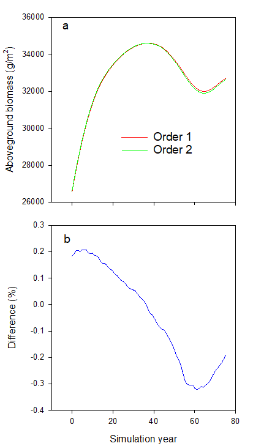

Figure 2: Differences in total landscape aboveground biomass when using two different input species orders for the same community. These simulations demonstrate how the sequential calculation of the competition index, combined with a lack of explicit species ordering affect the overall landscape aboveground biomass in time when using different input species orders (see Table 8). In order to prevent differences introduced by cohort recruitment, species’ ages at sexual maturity were changed to the species’ longevity values, and the simulation ran for 75 years to prevent any cohorts from reaching sexual maturity. The bottom panel shows the difference between the two simulations in percentage, calculated as $\frac{Biomass_{order2} - Biomass_{order1}}{Biomass_{order2}} * 100$

Third, in LBSE the calculation of total pixel biomass for the purpose of calculating the initial biomass of a new cohort included the (previously calculated) biomass of other new cohorts when succession time step = 1, but not when time step was > 1. This does not reflect the documentation in the User’s Guide, which stated that “*Bsum [total pixel biomass] is the current total biomass for the site (not including other new cohorts)*” (Scheller & Miranda 2015), when the succession time step was set to 1. Additionally, together with the lack of explicit ordering, this generated different results in terms of the biomass assigned to each new cohort (e.g., Table 9 and Fig. 3). In *Biomass_core* the initial biomass of new cohorts is no longer calculated sequentially (as with competition, growth and mortality), and thus the biomass of new cohorts is never included in the calculation of total pixel biomass.

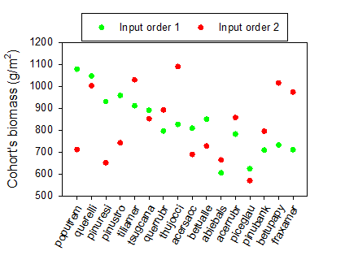

Figure 3: Differences in the biomass assigned to new cohorts, summed for each species across pixels, when using two different input species orders for the same community and when the succession time step is 1. These simulations demonstrate how the different summation of total cohort biomass for a succession time step of 1 and the lack of explicit species ordering affect simulation results when changing the species order in the input file (see Table 9). Here, initial cohort ages were also set to 1. Values refer to the initial total biomass attributed to each species at the end of year 1.

Fourth, in LBSE, serotiny and resprouting could not occur in the same pixel following a fire, with serotiny taking precedence if activated. We understand that this provides an advantage to serotinous species, which could perhaps be disadvantaged with respect to fast-growing resprouters. However, we feel that it is ecologically more realistic that serotinous and resprouter species be able to both regenerate in a given pixel following a fire and allow the competition between serotinous and resprouting species to arise from species traits. Note that this change was implemented in the *Biomass_regeneration* and *Biomass_regenerationPM* modules, since post-disturbance effects were separated background vegetation dynamics simulated by *Biomass_core*.

Fifth, in *Biomass_core*, species shade tolerance values can have decimal values to allow for finer adjustments of between-species competition.

#### Other enhancements

##### Modularity

Unlike in LBSE, post-disturbance effects are not part of *Biomass_core* *per se*, but belong to two separate modules, used interchangeably ([*Biomass_regeneration*](https://github.com/PredictiveEcology/Biomass_regeneration/blob/master/Biomass_regeneration.Rmd) and [*Biomass_regenerationPM*](https://github.com/PredictiveEcology/Biomass_regenerationPM/blob/master/Biomass_regenerationPM.Rmd)). These need to be loaded and added to the “modules folder” of the project in case the user wants to simulate forest responses to disturbances (only fire disturbances at the moment). Again, this enables higher flexibility when swapping between different approaches to regeneration.

Climate effects on growth and mortality were also implemented a modular way. The effects of climate on biomass increase (growth) and loss (mortality) were written in functions grouped in two packages. The `LandR` R package contains default, “non-climate-sensitive” functions, while the `LandR.CS` R package contains the functions that simulate climate effects (CS stands for “climate sensitive”). Note that these functions do not simulate actual growth/mortality processes, but estimate modifiers that increase/decrease cohort biomass on top of background growth/mortality. *Biomass_core* uses the `LandR` functions by default (see `growthAndMortalityDrivers` parameter in the full parameters list). Should the user wish to change how climate effects on growth/mortality are calculated, they can provide new compatible functions (i.e., with the same names, inputs and outputs) via another R package.

##### Hashing

Our first strategy to improve simulation efficiency in *Biomass_core* was to use a hashing mechanism (Yang *et al.* 2011). Instead of assigning a key to each pixel in a raster and tracking the simulation for each pixel in a lookup table, we indexed pixels using a *pixelGroup* key that contained unique combinations of ecolocation and community composition (i.e., species, age and biomass composition), and tracked and stored simulation data for each *pixelGroup* (Fig. 4). This algorithm was able to ease the computational burden by significantly reducing the size of the lookup table and speeding-up the simulation process. After recruitment and disturbance events, pixels are rehashed into new pixel groups.

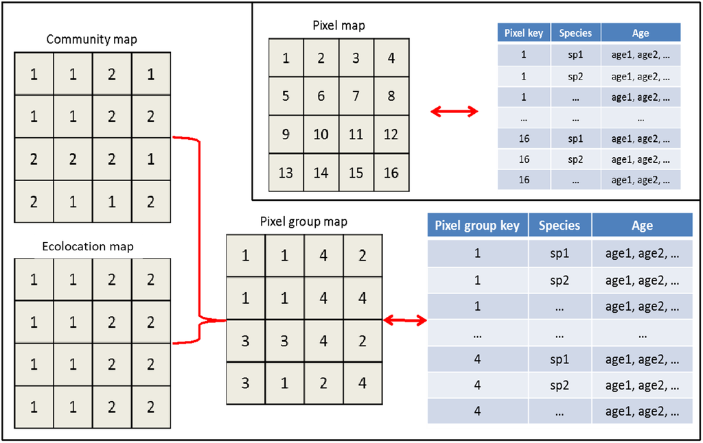

Figure 4: Hashing design for *Biomass_core*. In the re-coded *Biomass_core*, the pixel group map was hashed based on the unique combination of species composition (‘community map’) and ecolocation map, and associated with a lookup table. The insert in the top-right corner was the original design that linked the map to the lookup table by pixel key.

##### Caching

The second strategy aimed at improving model efficacy was the implementation of caching during data-driven parametrisation and initialisation. Caching automatically archives outputs of a given function to disk (or memory) and reads them back when subsequent calls of this function are given identical inputs. All caching operations were achieved using the `reproducible` R package (McIntire & Chubaty 2020).

In the current version of *Biomass_core*, the spin-up phase was replaced by data-driven landscape initialisation and many model parameters were derived from data, using data and calibration modules (e.g., *Biomass_borealDataPrep*). To avoid having to repeat data downloads and treatment, statistical estimation of parameters and landscape initialisation every time the simulation is re-run under the same conditions, many of these pre-simulation steps are automatically cached. This means that the pre-simulation phase is significantly faster upon a second call when inputs have not changed (e.g., the input data and parametrisation methods), and when inputs do change only directly affected steps are re-run (see main text for examples). When not using data modules, *Biomass_core* still relies on caching for the preparation of its theoretical inputs.

##### Testing

Finally, we implemented code testing to facilitate bug detection by comparing the outputs of functions (etc.) to expected outputs (Wickham 2011). We built and integrated code tests in *Biomass_core* and across all LandR modules and the `LandR` R package in the form of assertions, unit tests and integration tests. Assertions and unit tests are run automatically during simulations (but can be turned off) and evaluate individual code components (e.g., one function or an object’s class). Integration tests evaluate if several coded processes are integrated correctly and are usually run manually. However, because we embedded assertions within the module code, R package dependencies of *Biomass_core*, such as the `LandR` R package and `SpaDES`, they also provide a means to test module integration. We also implemented GitHub Actions continuous integration (CI), which routinely test GitHub hosted packages (e.g., `LandR`) and modules. CRAN-hosted packages (e.g., `SpaDES`) are also automatically tested and checked on CRAN.

Finally, because *Biomass_core* (and all other LandR modules) code is hosted in public GitHub repositories, the module code is subject to the scrutiny of many users, who can identify issues and contribute to improve module code.

#### Performance and accuracy of *Biomass_core* with respect to LBSE

In the recoding of *Biomass_core*, we used integration tests to ensured similar outputs of each demographic process (namely, growth, mortality and recruitment) to the outputs from its counterpart in LBSE. Here, we report the comparisons of the overall simulation (i.e., including all demographic processes) between LBSE and *Biomass_core* using three randomly generated initial communities (Tables 10-12). The remaining input parameters were taken from a LANDIS-II training course (Tables 13-16), and contained species attributes information of 16 common tree species in boreal forests and 2 ecolocations. We ran simulations for 1000 years, with a succession time step of 10 and three replicates, which were enough to account for the variability produced by stochastic processes. Seed dispersal was set as “ward dispersal”.

The results suggested that *Biomass_core* had a good agreement with LBSE using the three randomly generated initial communities (Fig. 5), with very small deviations for LBSE-generated biomasses. Notably, the mean differences between LBSE and *Biomass_core* were 0.03% (range: -0.01% ~ 0.13%), 0.03% (range: -0.01% ~ 0.11%) and 0.05% (-0.02% ~ 0.15%) for each initial community, respectively (right panels in Fig. 5 of this appendix).

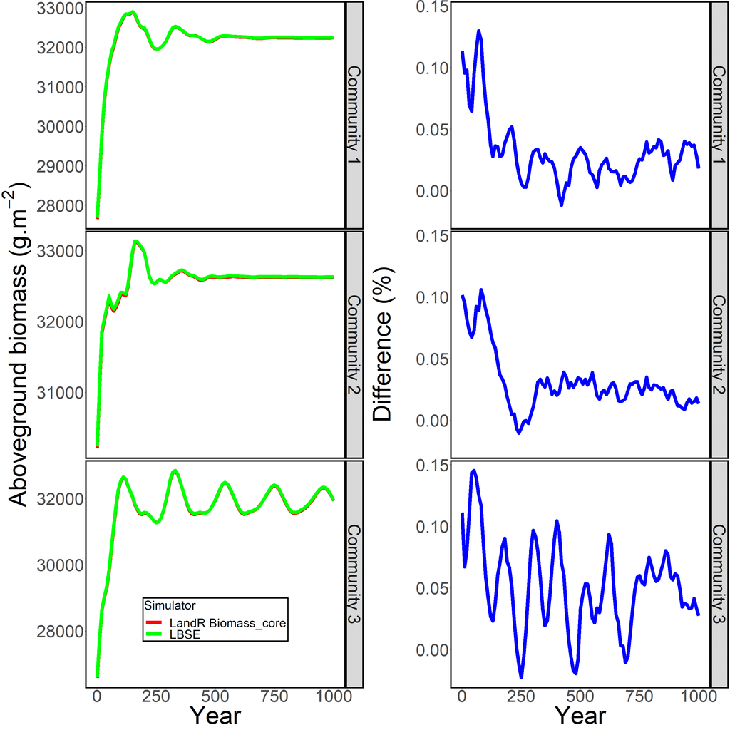

Figure 5: Visual comparison of simulation outputs for three randomly generated initial communities (left panels) and difference between those outputs (right panels). The % difference between LBSE and *Biomass_core* were calculated as $\frac{Biomass_{LBSE} - Biomass_{Biomass_core}}{Biomass_{LBSE}} * 100$

To examine how running time changed with map size, we ran simulations using maps with increasing number of pixels, from 22,201 to 638,401 pixels. All maps were initialised with a single ecolocation and 7 different communities. Simulations were run for 120 years using a succession time step of 10 and replicated three times. To eliminate the effect of hardware on running time, we used machines that were all purchased at the same time, with equal specifications and running Windows 7. Each simulation ran on 2 CPU threads with a total RAM of 4000 Mb.

For both LBSE and *Biomass_core*, the simulation time increased linearly with number of pixels, but the increase rate was smaller for *Biomass_core* (Fig. 6a). This meant that while both models had similar simulation efficiencies in small maps (< 90,000 pixels), as map size increased *Biomass_core* was ~2 times faster than LBSE (maps > 100,000 pixels; Fig. 6a). *Biomass_core* also scaled better with map size, as LBSE speeds fluctuated between 19 to 25 seconds per 1,000 pixels across all map sizes, while *Biomass_core* decreased from 21 to 11 seconds per 1,000 pixels from smaller to larger maps (Fig. 6b).

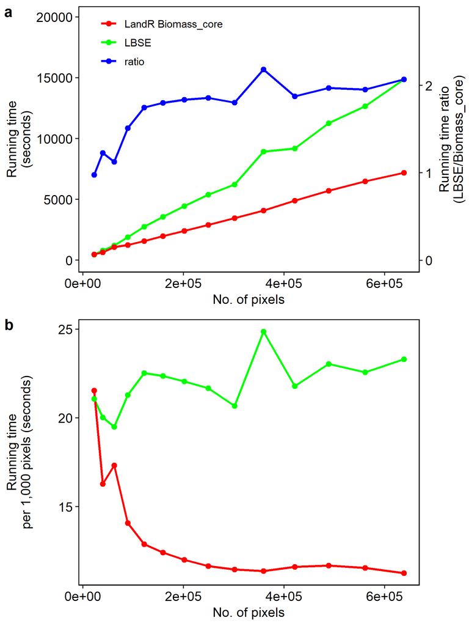

Figure 6: Simulation efficiencies of LBSE and *Biomass_core* with increasing map size, in terms of a) mean running time across repetitions (left y-axis) and the ratio LBSE to *Biomass_core* running times (right y-axis and blue line), and b) running time scalability as the mean running time per 1000 pixels.

## Usage example

### Set up R libraries

```r
options(repos = c(CRAN = "https://cloud.r-project.org"))
tempDir <- tempdir()

pkgPath <- file.path(tempDir, "packages", version$platform,
                     paste0(version$major, ".", strsplit(version$minor, "[.]")[[1]][1]))
dir.create(pkgPath, recursive = TRUE)
.libPaths(pkgPath, include.site = FALSE)

if (!require(Require, lib.loc = pkgPath)) {
  remotes::install_github("PredictiveEcology/Require@5c44205bf407f613f53546be652a438ef1248147",
                          upgrade = FALSE, force = TRUE)
  library(Require, lib.loc = pkgPath)
}

setLinuxBinaryRepo()
```

### Get the module and module dependencies

We can use the `SpaDES.project::getModule` function to download the module to the module folder specified above. Alternatively, see [SpaDES-modules repository](https://github.com/PredictiveEcology/SpaDES-modules) to see how to download this and other `SpaDES` modules, or fork/clone from its [GitHub repository](https://github.com/PredictiveEcology/Biomass_core/) directly.

After downloading the module, it is important to make sure all module R package dependencies are installed in their correct version. `SpaDES.project::packagesInModules` makes a list of necessary packages for all modules in the `paths$modulePath`, and `Require` installs them.

```r
Require("PredictiveEcology/SpaDES.project@6d7de6ee12fc967c7c60de44f1aa3b04e6eeb5db",
        require = FALSE, upgrade = FALSE, standAlone = TRUE)

paths <- list(inputPath = normPath(file.path(tempDir, "inputs")),
              cachePath = normPath(file.path(tempDir, "cache")),
              modulePath = normPath(file.path(tempDir, "modules")),
              outputPath = normPath(file.path(tempDir, "outputs")))

SpaDES.project::getModule(modulePath = paths$modulePath,
                          c("PredictiveEcology/Biomass_core@master"),
                          overwrite = TRUE)

## make sure all necessary packages are installed:
outs <- SpaDES.project::packagesInModules(modulePath = paths$modulePath)
Require(c(unname(unlist(outs)), "SpaDES"),
        require = FALSE, standAlone = TRUE)

## load necessary packages
Require(c("SpaDES", "LandR", "reproducible", "pemisc"),
        upgrade = FALSE, install = FALSE)
```

### Setup simulation

Here we setup a simulation in a random study area, using any species within the `LandR::sppEquivalencies_CA` table that can be found there (*Biomass_core* will retrieve species % cover maps and filter present species). We also define the colour coding used for plotting, the type of plots we what to produce and choose to output `cohortData` tables every year – note that these are not pixel-based, so to “spatialise” results *a posteriori* the `pixelBroupMap` must also be saved.

Please see the lists of input objects, parameters and outputs for more information.

```r
times <- list(start = 0, end = 30)

studyArea <- Cache(randomStudyArea, size = 1e7) # cache this so it creates a random one only once on a machine

# Pick the species you want to work with – using the naming convention in "Boreal" column of LandR::sppEquivalencies_CA
speciesNameConvention <- "Boreal"
speciesToUse <- c("Pice_Gla", "Popu_Tre", "Pinu_Con")

sppEquiv <- sppEquivalencies_CA[get(speciesNameConvention) %in% speciesToUse]
# Assign a colour convention for graphics for each species
sppColorVect <- sppColors(sppEquiv, speciesNameConvention,
                          newVals = "Mixed", palette = "Set1")

## Usage example
modules <- as.list("Biomass_core")
objects <- list(studyArea = studyArea, sppEquiv = sppEquiv, sppColorVect = sppColorVect)

successionTimestep <- 10L

## keep default values for most parameters
## (omitted from this list)
parameters <- list(
  Biomass_core = list(
    "sppEquivCol" = speciesNameConvention
    , "successionTimestep" = successionTimestep
    , ".plots" = c("screen", "object")
    , ".plotInitialTime" = times$start
    , ".plots" = c("screen", "png")
    , ".saveInitialTime" = times$start
    , ".useCache" = "init"
    , ".useParallel" = FALSE
  )
)

outputs <- data.frame(expand.grid(objectName = "cohortData",
                                  saveTime = unique(seq(times$start, times$end, by = 1)),
                                  eventPriority = 1,
                                  stringsAsFactors = FALSE))
```

### Run simulation

`simInitAndSpades` is a wrapper function that runs both `simInit` (which initialises all modules) and `spades` (which runs all modules, i.e., their events), to which pass all the necessary setup objects created above.

Below, we pass some useful `reproducible` options that control caching (`"reproducible.useCache"`) and where inputs should be downloaded to (`"reproducible.destinationPath"`).

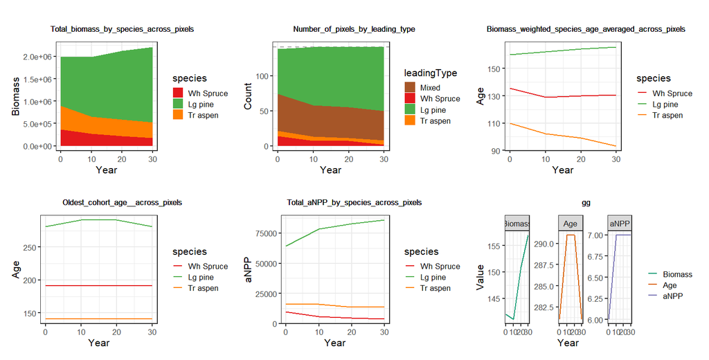

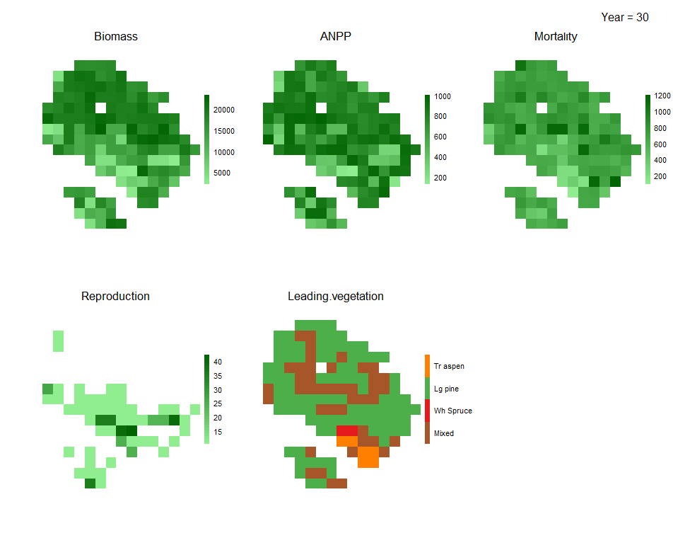

Figure 7: *Biomass_core* automatically generates simulation visuals of species dynamics across the landscape in terms of total biomass, number of presences and age and productivity (above), as well as yearly plots of total biomass, productivity, mortality, reproduction and leading species in each pixel (below).

```r
opts <- options(reproducible.useCache = TRUE,
                reproducible.destinationPath = paths$inputPath,
                spades.useRequire = FALSE)
graphics.off()
mySim <- simInitAndSpades(times = times,
                          params = parameters,
                          modules = modules,
                          objects = objects,
                          paths = paths,
                          outputs = outputs,
                          debug = TRUE)
```

## Appendix

### Tables

Table 8: Input order and processing order (as determined by LBSE) for the same community used to assess the impact of sequential calculation of the competition index, combined with a lack of explicit species ordering. The input order was the order of species in the initial communities table input file. The processing order was the order used in the simulation, which was obtained from `Landis-log.txt` when `CalibrateMode` was set to ‘yes’. Species starting ages are also shown.

| Input order 1 |  |  |  | Input order 2 |  |  |  |
| --- | --- | --- | --- | --- | --- | --- | --- |
| Community | Input order | Age | Processing | Community | Input order | Age | Processing |
| 1 | abiebals | 20 | poputrem | 1 | pinustro | 20 | thujocci |
| 1 | acerrubr | 20 | querelli | 1 | poputrem | 20 | tiliamer |
| 1 | acersacc | 20 | pinuresi | 1 | acerrubr | 20 | querelli |
| 1 | betualle | 20 | pinustro | 1 | pinubank | 20 | querrubr |
| 1 | betupapy | 20 | tiliamer | 1 | betualle | 20 | betupapy |
| 1 | fraxamer | 20 | tsugcana | 1 | piceglau | 20 | fraxamer |
| 1 | piceglau | 20 | querrubr | 1 | pinuresi | 20 | tsugcana |
| 1 | pinubank | 20 | thujocci | 1 | acersacc | 20 | abiebals |
| 1 | pinuresi | 20 | acersacc | 1 | querelli | 20 | acerrubr |
| 1 | pinustro | 20 | betualle | 1 | querrubr | 20 | pinubank |
| 1 | poputrem | 20 | abiebals | 1 | thujocci | 20 | pinustro |
| 1 | querelli | 20 | acerrubr | 1 | tiliamer | 20 | poputrem |
| 1 | querrubr | 20 | piceglau | 1 | tsugcana | 20 | pinuresi |
| 1 | thujocci | 20 | pinubank | 1 | abiebals | 20 | acersacc |
| 1 | tiliamer | 20 | betupapy | 1 | betupapy | 20 | betualle |
| 1 | tsugcana | 20 | fraxamer | 1 | fraxamer | 20 | piceglau |

Table 9: Input order and processing order (as determined by LBSE) for the same community used to assess the impact of setting the succession time step to 1, combined with a lack of explicit species ordering. The input order was the order of species in the initial communities table input file. The processing order was the order used in the simulation, which was obtained from `Landis-log.txt` when `CalibrateMode` was set to ‘yes’. Species starting ages are also shown.

| Input order 1 |  |  |  | Input order 2 |  |  |  |
| --- | --- | --- | --- | --- | --- | --- | --- |
| Community | Input order | Age | Processing | Community | Input order | Age | Processing |
| 1 | abiebals | 1 | poputrem | 1 | pinustro | 1 | thujocci |
| 1 | acerrubr | 1 | querelli | 1 | poputrem | 1 | tiliamer |
| 1 | acersacc | 1 | pinuresi | 1 | acerrubr | 1 | querelli |
| 1 | betualle | 1 | pinustro | 1 | pinubank | 1 | querrubr |
| 1 | betupapy | 1 | tiliamer | 1 | betualle | 1 | betupapy |
| 1 | fraxamer | 1 | tsugcana | 1 | piceglau | 1 | fraxamer |
| 1 | piceglau | 1 | querrubr | 1 | pinuresi | 1 | tsugcana |
| 1 | pinubank | 1 | thujocci | 1 | acersacc | 1 | abiebals |
| 1 | pinuresi | 1 | acersacc | 1 | querelli | 1 | acerrubr |
| 1 | pinustro | 1 | betualle | 1 | querrubr | 1 | pinubank |
| 1 | poputrem | 1 | abiebals | 1 | thujocci | 1 | pinustro |
| 1 | querelli | 1 | acerrubr | 1 | tiliamer | 1 | poputrem |
| 1 | querrubr | 1 | piceglau | 1 | tsugcana | 1 | pinuresi |
| 1 | thujocci | 1 | pinubank | 1 | abiebals | 1 | acersacc |
| 1 | tiliamer | 1 | betupapy | 1 | betupapy | 1 | betualle |
| 1 | tsugcana | 1 | fraxamer | 1 | fraxamer | 1 | piceglau |

Table 10: Randomly generated community combination no. 1 used in the recruitment comparison runs.

| Community | Species | Age 1 | Age 2 | Age 3 | Age 4 | Age 5 | Age 6 | Age 7 |
| --- | --- | --- | --- | --- | --- | --- | --- | --- |
| 0 | betupapy | 1 | 37 | 45 | 46 | 85 | NA | NA |
| 0 | piceglau | 27 | 73 | 153 | 256 | 270 | NA | NA |
| 0 | pinustro | 157 | 159 | 181 | 220 | 223 | 303 | 307 |
| 0 | querrubr | 80 | 102 | 127 | 152 | 206 | 227 | NA |
| 1 | acerrubr | 3 | 91 | 126 | 145 | NA | NA | NA |
| 1 | acersacc | 138 | 144 | 276 | NA | NA | NA | NA |
| 1 | betualle | 24 | 106 | 136 | 149 | 279 | NA | NA |
| 1 | piceglau | 27 | 67 | 70 | 153 | NA | NA | NA |
| 1 | pinubank | 3 | 10 | 24 | 31 | 71 | NA | NA |
| 1 | querelli | 92 | 224 | 234 | NA | NA | NA | NA |
| 1 | thujocci | 73 | 146 | 262 | NA | NA | NA | NA |
| 2 | fraxamer | 108 | 118 | 137 | 147 | 204 | NA | NA |
| 2 | piceglau | 40 | 128 | 131 | 159 | 174 | NA | NA |
| 2 | pinustro | 78 | 156 | 237 | 245 | 270 | NA | NA |
| 2 | querelli | 67 | 97 | 186 | 292 | NA | NA | NA |
| 2 | tiliamer | 70 | 103 | 121 | 152 | 178 | 180 | 245 |
| 3 | acerrubr | 5 | 83 | 125 | 126 | 127 | NA | NA |
| 3 | pinuresi | 1 | 25 | 42 | 49 | 76 | 79 | 103 |
| 3 | poputrem | 4 | 9 | 62 | NA | NA | NA | NA |
| 3 | querelli | 101 | 104 | 167 | 226 | NA | NA | NA |
| 3 | tsugcana | 37 | 135 | 197 | 404 | 405 | NA | NA |
| 4 | acerrubr | 15 | 29 | 63 | 70 | 105 | 133 | NA |
| 4 | piceglau | 67 | 132 | 189 | NA | NA | NA | NA |
| 4 | tsugcana | 21 | 26 | 110 | 146 | 341 | 462 | 463 |
| 5 | acerrubr | 128 | 137 | 145 | 147 | NA | NA | NA |
| 5 | acersacc | 241 | 245 | 261 | 277 | NA | NA | NA |
| 5 | querrubr | 23 | 72 | 120 | 142 | 188 | NA | NA |
| 5 | tiliamer | 4 | 68 | 98 | 118 | 139 | 197 | NA |
| 6 | betualle | 5 | 23 | 31 | 249 | NA | NA | NA |
| 6 | pinubank | 67 | 70 | 89 | NA | NA | NA | NA |
| 6 | querelli | 194 | 217 | 257 | NA | NA | NA | NA |

Table 11: Randomly generated community combination no. 2 used in the recruitment comparison runs.

| Community | Species | Age 1 | Age 2 | Age 3 | Age 4 | Age 5 | Age 6 | Age 7 |
| --- | --- | --- | --- | --- | --- | --- | --- | --- |
| 0 | acerrubr | 22 | 26 | 30 | 40 | 47 | 145 | 146 |
| 0 | betualle | 23 | 41 | 43 | 120 | 209 | 227 | 270 |
| 0 | fraxamer | 25 | 90 | 119 | 173 | 185 | 282 | NA |
| 0 | pinuresi | 48 | 53 | 70 | 121 | 157 | NA | NA |
| 0 | pinustro | 5 | 82 | 126 | 298 | 352 | NA | NA |
| 0 | querrubr | 2 | 30 | 34 | 74 | 77 | 162 | 245 |
| 1 | acerrubr | 2 | 39 | 43 | 84 | 116 | 127 | 143 |
| 1 | pinubank | 34 | 57 | 75 | NA | NA | NA | NA |
| 1 | querelli | 108 | 202 | 218 | 243 | NA | NA | NA |
| 1 | querrubr | 5 | 117 | 131 | 186 | 189 | 246 | NA |
| 1 | tiliamer | 10 | 19 | 46 | 80 | 133 | 148 | 231 |
| 1 | tsugcana | 31 | 48 | 190 | 246 | 330 | NA | NA |
| 2 | pinubank | 11 | 37 | 38 | 47 | 67 | 93 | NA |
| 2 | querrubr | 11 | 48 | 57 | 177 | 180 | 228 | 236 |
| 2 | tiliamer | 28 | 42 | 78 | 79 | 223 | 250 | NA |
| 2 | tsugcana | 140 | 202 | 372 | 381 | 451 | NA | NA |
| 3 | acersacc | 48 | 107 | 262 | 265 | NA | NA | NA |
| 3 | betupapy | 4 | 12 | 45 | 65 | 83 | 96 | NA |
| 3 | poputrem | 13 | 20 | 37 | 75 | 90 | NA | NA |
| 3 | querelli | 72 | 90 | 104 | 115 | 116 | 265 | 278 |
| 3 | tiliamer | 20 | 21 | 56 | 98 | 237 | NA | NA |
| 3 | tsugcana | 86 | 224 | 425 | 429 | NA | NA | NA |
| 4 | fraxamer | 77 | 133 | 181 | NA | NA | NA | NA |
| 4 | pinustro | 13 | 37 | 67 | 220 | 287 | 293 | 375 |
| 4 | querrubr | 27 | 48 | 89 | 97 | NA | NA | NA |
| 4 | thujocci | 91 | 244 | 305 | 390 | NA | NA | NA |
| 5 | abiebals | 86 | 95 | 119 | 121 | 127 | 158 | NA |
| 5 | betualle | 83 | 113 | 136 | 161 | 216 | 231 | NA |
| 5 | betupapy | 10 | 38 | 64 | NA | NA | NA | NA |
| 5 | piceglau | 16 | 63 | 70 | 102 | NA | NA | NA |
| 6 | acerrubr | 8 | 34 | 112 | NA | NA | NA | NA |
| 6 | betupapy | 1 | 31 | 57 | 61 | 74 | 80 | 91 |
| 6 | fraxamer | 63 | 100 | 108 | 140 | 196 | 294 | NA |
| 6 | pinubank | 15 | 19 | 44 | 47 | 51 | 80 | NA |
| 6 | thujocci | 78 | 146 | 163 | 213 | 214 | 228 | NA |
| 6 | tsugcana | 47 | 108 | 387 | 389 | 449 | NA | NA |

Table 12: Randomly generated community combination no. 3 used in the recruitment comparison runs.

| Community | Species | Age 1 | Age 2 | Age 3 | Age 4 | Age 5 | Age 6 | Age 7 |
| --- | --- | --- | --- | --- | --- | --- | --- | --- |
| 0 | pinubank | 7 | 26 | 32 | 37 | 48 | 85 | 90 |
| 0 | pinuresi | 11 | 103 | 109 | 179 | 188 | 197 | NA |
| 0 | querrubr | 89 | 139 | 180 | 206 | NA | NA | NA |
| 1 | betupapy | 36 | 39 | 45 | 49 | 66 | 68 | NA |
| 1 | piceglau | 13 | 165 | 254 | NA | NA | NA | NA |
| 1 | pinubank | 3 | 19 | 54 | 64 | 76 | NA | NA |
| 1 | poputrem | 22 | 59 | 93 | NA | NA | NA | NA |
| 1 | thujocci | 68 | 98 | 274 | 275 | 363 | 378 | NA |
| 1 | tiliamer | 13 | 20 | 105 | 124 | 248 | NA | NA |
| 1 | tsugcana | 36 | 90 | 142 | NA | NA | NA | NA |
| 2 | fraxamer | 11 | 241 | 279 | NA | NA | NA | NA |
| 2 | piceglau | 16 | 42 | 129 | 177 | 200 | 244 | NA |
| 2 | pinustro | 200 | 342 | 384 | NA | NA | NA | NA |
| 3 | abiebals | 31 | 57 | 61 | 92 | 108 | 162 | 183 |
| 3 | piceglau | 126 | 255 | 261 | 267 | NA | NA | NA |
| 3 | poputrem | 28 | 41 | 57 | NA | NA | NA | NA |
| 3 | querrubr | 83 | 91 | 144 | 173 | 184 | 238 | NA |
| 3 | thujocci | 6 | 66 | 68 | 204 | NA | NA | NA |
| 4 | fraxamer | 12 | 110 | 266 | 270 | NA | NA | NA |
| 4 | pinustro | 174 | 270 | 359 | 379 | NA | NA | NA |
| 4 | poputrem | 4 | 7 | 18 | 24 | 63 | 76 | NA |
| 4 | tiliamer | 126 | 136 | 197 | NA | NA | NA | NA |
| 4 | tsugcana | 49 | 91 | 128 | 194 | 411 | 487 | NA |
| 5 | abiebals | 35 | 53 | 108 | 114 | 147 | 174 | 195 |
| 5 | acerrubr | 1 | 2 | 101 | 145 | NA | NA | NA |
| 5 | pinubank | 14 | 15 | 38 | 40 | 59 | 69 | 83 |
| 6 | acerrubr | 4 | 46 | 117 | NA | NA | NA | NA |
| 6 | betualle | 36 | 41 | 116 | 213 | 253 | NA | NA |
| 6 | betupapy | 4 | 6 | 76 | NA | NA | NA | NA |
| 6 | pinuresi | 43 | 68 | 85 | 171 | NA | NA | NA |
| 6 | querrubr | 84 | 86 | 113 | 185 | 193 | 223 | 228 |
| 6 | tiliamer | 13 | 106 | 181 | 199 | 246 | NA | NA |

Table 13: Invariant species traits table used in comparison runs.

| Species | Longevity | Sexualmature | Shadetolerance | Seeddistance_eff | Seeddistance_max | Mortalityshape | Growthcurve |
| --- | --- | --- | --- | --- | --- | --- | --- |
| abiebals | 200 | 25 | 5 | 30 | 160 | 10 | 0.25 |
| acerrubr | 150 | 10 | 4 | 100 | 200 | 10 | 0.25 |
| acersacc | 300 | 40 | 5 | 100 | 200 | 10 | 0.25 |
| betualle | 300 | 40 | 4 | 100 | 400 | 10 | 0.25 |
| betupapy | 100 | 30 | 2 | 200 | 5000 | 10 | 0.25 |
| fraxamer | 300 | 30 | 4 | 70 | 140 | 10 | 0.25 |
| piceglau | 300 | 25 | 3 | 30 | 200 | 10 | 0.25 |
| pinubank | 100 | 15 | 1 | 20 | 100 | 10 | 0.25 |
| pinuresi | 200 | 35 | 2 | 20 | 275 | 10 | 0.25 |
| pinustro | 400 | 40 | 3 | 60 | 210 | 10 | 0.25 |
| poputrem | 100 | 20 | 1 | 1000 | 5000 | 10 | 0.25 |
| querelli | 300 | 35 | 2 | 30 | 3000 | 10 | 0.25 |
| querrubr | 250 | 25 | 3 | 30 | 3000 | 10 | 0.25 |
| thujocci | 400 | 30 | 2 | 45 | 60 | 10 | 0.25 |
| tiliamer | 250 | 30 | 4 | 30 | 120 | 10 | 0.25 |
| tsugcana | 500 | 30 | 5 | 30 | 100 | 10 | 0.25 |

Table 14: Minimum relative biomass table used in comparison runs. X0-5 represent site shade classes from no-shade (0) to maximum shade (5). All ecolocations shared the same values.

| Ecolocation | X0 | X1 | X2 | X3 | X4 | X5 |
| --- | --- | --- | --- | --- | --- | --- |
| All | 0 | 0.15 | 0.25 | 0.5 | 0.8 | 0.95 |

Table 15: Probability of germination for species shade tolerance and shade level combinations (called *sufficient light* table in LBSE and `sufficientLight` input `data.table` in LandR *Biomass_core*) used in comparison runs.

| Shadetolerance | 0 | 1 | 2 | 3 | 4 | 5 |
| --- | --- | --- | --- | --- | --- | --- |
| 1 | 1 | 0 | 0 | 0 | 0 | 0 |
| 2 | 1 | 1 | 0 | 0 | 0 | 0 |
| 3 | 1 | 1 | 1 | 0 | 0 | 0 |
| 4 | 1 | 1 | 1 | 1 | 0 | 0 |
| 5 | 0 | 0 | 1 | 1 | 1 | 1 |

Table 16: Species ecolocation table used in comparison runs. `SEP` stands for species establishment probability, `maxB` for maximum biomass and `maxANPP` for maximum aboveground net primary productivity. Values were held constant throughout the simulation.

| Ecolocation | Species | SEP | maxANPP | maxB |
| --- | --- | --- | --- | --- |
| 1 | abiebals | 0.90 | 886 | 26580 |
| 1 | acerrubr | 1.00 | 1175 | 35250 |
| 1 | acersacc | 0.82 | 1106 | 33180 |
| 1 | betualle | 0.64 | 1202 | 36060 |
| 1 | betupapy | 1.00 | 1202 | 36060 |
| 1 | fraxamer | 0.18 | 1202 | 36060 |
| 1 | piceglau | 0.58 | 969 | 29070 |
| 1 | pinubank | 1.00 | 1130 | 33900 |
| 1 | pinuresi | 0.56 | 1017 | 30510 |
| 1 | pinustro | 0.72 | 1090 | 38150 |
| 1 | poputrem | 1.00 | 1078 | 32340 |
| 1 | querelli | 0.96 | 1096 | 32880 |
| 1 | querrubr | 0.66 | 1017 | 30510 |
| 1 | thujocci | 0.76 | 1090 | 32700 |
| 1 | tiliamer | 0.54 | 1078 | 32340 |
| 1 | tsugcana | 0.22 | 1096 | 32880 |

## References

Burton, P.J. & Cumming, S.G. (1995). Potential effects of climatic change on some western canadian forests, based on phenological enhancements to a patch model of forest succession. *Water, Air and Soil Pollution*, 82, 401–414.

Chubaty, A.M. & McIntire, E.J.B. (2019). *[SpaDES: Develop and run spatially explicit discrete event simulation models](https://CRAN.R-project.org/package=SpaDES)*.

Guindon, L., Manka, F., Correia, D.L.P., Villemaire, P., Smiley, B., Bernier, P., *et al.* (2024). [A new approach for spatializing the Canadian National Forest Inventory (SCANFI) using Landsat dense time series](https://doi.org/10.1139/cjfr-2023-0118). *Canadian Journal of Forest Research*, 54, 793–815.

Guindon, L., Villemaire, P., Correia, D.L.P., Manka, F., Lacarte, S. & Smiley, B. (2023). [SCANFI: The Spatialized CAnadian National Forest Inventory data product](https://doi.org/10.23687/18E6A919-53FD-41CE-B4E2-44A9707C52DC).

McIntire, E.J.B. & Chubaty, A.M. (2020). *[Reproducible: A set of tools that enhance reproducibility beyond package management](https://reproducible.predictiveecology.org,%20https://github.com/PredictiveEcology/reproducible)*.

Scheller, R.M. & Domingo, J.B. (2011). *LANDIS-II model v6.0 – user guide*.

Scheller, R.M. & Domingo, J.B. (2012). *LANDIS-II model v6.0 – conceptual description*.

Scheller, R.M. & Miranda, B.R. (2015). *LANDIS-II biomass succession v3.2 extension – user guide*.

Scheller, R.M. & Mladenoff, D.J. (2004). [A forest growth and biomass module for a landscape simulation model, LANDIS: Design, validation, and application](https://doi.org/10.1016/j.ecolmodel.2004.01.022). *Ecological Modelling*, 180, 211–229.

Sturtevant, B.R., Miranda, B.R., Scheller, R.M. & Shinneman, D. (2018). *LANDIS-II dynamic fire system extension v3.0 – user guide*.

Wickham, H. (2011). [Testthat: Get started with testing](https://doi.org/10.32614/RJ-2011-002). *The R Journal*, 3, 5.

Yang, J., He, H.S., Shifley, S.R., Thompson, F.R. & Zhang, Y. (2011). [An innovative computer design for modeling forest landscape change in very large spatial extents with fine resolutions](https://doi.org/10.1016/j.ecolmodel.2011.04.032). *Ecological Modelling*, 222, 2623–2630.

[^1]: in LBSE the initialisation consists in “iterat[ing] the number of time steps equal to the maximum cohort age for each site”, beginning at 0 minus *t* (*t =* oldest cohort age) and adding cohorts at the appropriate time until the initial simulation time is reached (0) (Scheller & Miranda 2015).
[^2]: usually, default inputs are made when running the `.inputObjects` function (inside the module R script) during the `simInit` call and in the `init` event during the `spades` call – see `?SpaDES.core::events` and `SpaDES.core::simInit`
[^3]: in `SpaDES` lingo parameters are “small” objects, such as an integer or boolean, that can be controlled via the `parameters` argument in `simInit`.
[^4]: https://github.com/ianmseddy/LandR.CS
[^5]: see `?SpaDES.core::outputs`
[^6]: `simInit` is a `SpaDES` function that initialises the execution of one or more modules by parsing and checking their code and executing the `.inputObjects` function(s), where the developer provides mechanisms to satisfy each module’s expected inputs with default values.